# CHE-226: Programming and AI for Chemical Engineers

### Topic 1 — Introduction to Computers, Python, and Data Science

Dr. Haider Ejaz School of Chemical and Materials Engineering (SCME), NUST

### Today's Roadmap

1. Welcome, syllabus & how this course works
2. Computers 101 — hardware, software, data
3. From machine code to Python — languages & objects
4. Why Python? — the library ecosystem
5. **Python in Action** — solving chemical engineering problems
6. Internet → Cloud → IoT → Big Data
7. AI: where CS meets data science

### About Me

🎓 SCME (NUST) → MS Energy Systems, USPCASE (semester at ASU) 💼 Research Associate, USPCASE 🌍 Fulbright Scholar — PhD Chemical & Biochemical Engineering, Rutgers 🔬 Research: DFT (VASP), Python-based data automation, Kinetic Monte Carlo (ZACROS)

### Course at a Glance

CHE-226 = Python programming **+** engineering data analysis, taught through chemical engineering problems, not syntax drills.

Three blocks: Programming fundamentals → NumPy/Pandas/Matplotlib → intro AI/ML (scikit-learn)

2 lecture hours + 3 lab hours per week

### How You'll Be Graded

**Theory (75%)** — Assignments 10% · Quizzes 10% · Midterm 25% · Project 15% · Final 40%

**Practical (25%)** — Lab reports/participation 10% · Lab quizzes/viva 5% · Mini project 10%

### Course Project

Teams of 3–5 · must connect to a chemical engineering problem · uses programming/data analysis

**Timeline:** Proposal (Wk 4) → Progress update (Wk 8) → Draft report (Wk 12) → Final report + presentation (Wk 14–15)

### Setting Up Jupyter Notebook

This is a preview, not something to do right now — you'll install and run this yourself in lab this week.

1. Install **Python** (check "Add Python to PATH")
2. Install Jupyter: `pip install notebook`
3. Run it: `jupyter notebook`
4. Opens automatically at `http://localhost:8888`

Create and run `.ipynb` notebooks from there — this is where almost all your coding this semester happens. In fact, **this lecture itself is one** — the slides you're looking at right now are a Jupyter notebook.

## Part 2: Computers, Data, and How They Fit Together

### 💡 Concept

A computer is **hardware** (physical: CPU, memory, sensors) driven by **software** (instructions you write — Python, Aspen, Excel).

Hardware gets faster and cheaper every year or two — this is **Moore's Law**.

### 💡 Concept — The Data Hierarchy

Bits build up into everything a computer stores:

**Bit → Byte → Field → Record → File → Database → Big Data**

Each level is just a meaningful grouping of the level below it.

### 🔍 Example

A student record: `("Ali Raza", "Chemical Eng.", 3.42)`

- Each **character** (A, l, i, …) is built from **bits**
- The name, major, GPA are each a **field**
- All three fields together = one **record**
- All students' records together = a **file** / **database**

### ✍️ Your Turn (2 min, no laptop needed)

With a neighbor — just talk it through:

1. Name **2 hardware** and **2 software** components in a lab instrument you've used (e.g. a pH meter, a GC).
2. Where would "today's reactor temperature reading" sit in the data hierarchy — field, record, or file?

### 💬 Check

Poll: *"Moore's Law says computing power roughly doubles every ___ months."* A) 6 B) 18–24 C) 60 D) It doesn't change

## Part 3: From Machine Code to Python

### 💡 Concept

Programming languages sit on a spectrum: **machine language** (raw 0s/1s) → **assembly** (symbolic shorthand) → **high-level languages** like Python (near-English).

Higher level = easier for humans, translated for you by a compiler/interpreter.

### 💡 Concept — Thinking in Objects

Python is **object-oriented**: data (attributes) and behavior (methods) are bundled into reusable **classes**.

A car's engineering drawing = a *class*. An actual car you drive = an *object* (instance).

### 🔍 Example

Same task, three languages:

```
+1300042774              # machine language
load basepay              # assembly
add overpay
store grosspay
grossPay = basePay + overTimePay   # high-level (Python-like)
```

Pressing the gas pedal = calling a **method** on the car **object**.

### ✍️ Your Turn (2 min, no laptop needed)

Think-pair-share: pick **one object** from a chemical plant (a pump, a tank, a sensor).

- What would its **attributes** be?
- What would its **methods** (actions) be?

### 💬 Check

Cold-call 2 pairs to share their object. Ask the room: *does everyone agree these are attributes, not methods (or vice versa)?*

## Part 4: Why Python?

### 💡 Concept

Python is popular because it's **readable, free, and backed by libraries** that do the hard work for you — you rarely start from scratch.

"It's the libraries!" — you write a few lines; the library does the heavy lifting.

### 🔍 Example — Libraries You'll Use This Semester

| Library | What it's for |
| --- | --- |
| **NumPy** | fast numerical arrays |
| **Pandas** | tabular data (like a spreadsheet in code) |
| **Matplotlib** | plots and charts |
| **scikit-learn** | machine learning |

### ✍️ Your Turn (2 min, no laptop needed)

Match each chemical engineering task to the library that fits best (NumPy / Pandas / Matplotlib / scikit-learn) — just call out your answer:

1. Plotting a titration curve
2. Cleaning a CSV of reactor sensor logs
3. Predicting yield from process conditions
4. Doing fast matrix math for a mass-balance model

### 💬 Check

Poll: *"Which library would you reach for first to clean messy data before analysis?"* A) NumPy B) Pandas C) Matplotlib D) scikit-learn

## Part 5: Python in Action — Solving Chemical Engineering Problems

We're not in the lab today, so this is a **narrated walkthrough**, not a type-along — I'll run the code on the screen and we'll reason about the numbers together. You'll get your hands on this exact material in lab this week.

Six short problems, all built from chemistry, mass and energy balances, and basic physics.

### Problem 1 — Reactor Temperature Readings

A reactor recorded temperatures (K) each minute for 8 minutes:

`T = [350, 352, 351, 355, 358, 360, 359, 361]`

**Tasks:** find the average, the minimum, the maximum, and check whether the reactor is warming overall.

### ✍️ Your Turn (30 sec, no laptop) — just eyeball the 8 numbers above: is this reactor warming or cooling overall? Shout out your guess.

```python
# Store the recorded reactor temperatures in a list
T = [350, 352, 351, 355, 358, 360, 359, 361]

# Calculate average temperature (sum divided by number of readings)
avg_T = sum(T) / len(T)

# Find minimum and maximum temperatures in the list
min_T = min(T)
max_T = max(T)

print("Average T (K):", avg_T)
print("Minimum T (K):", min_T)
print("Maximum T (K):", max_T)

# Check if reactor is warming overall: compare last and first reading
warming = T[-1] > T[0]
print("Warming overall?", warming)
```

```
Average T (K): 355.75
Minimum T (K): 350
Maximum T (K): 361
Warming overall? True
```

### 💬 Check

Where does this list of 8 readings sit in the data hierarchy from Part 2 — is it closer to a field, a record, or a file?

### 🎁 Bonus (if time allows) — Temperature vs. Time Plot

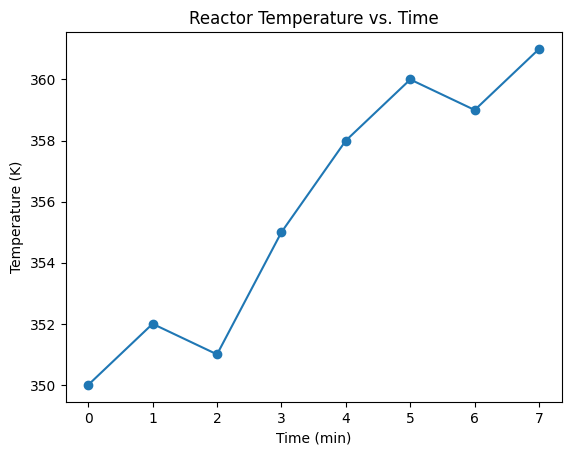

```python
import matplotlib.pyplot as plt

# Create time steps corresponding to measurements (0 to 7 minutes)
time_min = list(range(len(T)))

# Plot temperature vs. time
plt.plot(time_min, T, marker='o')
plt.xlabel("Time (min)")
plt.ylabel("Temperature (K)")
plt.title("Reactor Temperature vs. Time")
plt.show()
```

### Problem 2 — Density Calculation

Density = m / V

Suppose m = 500 kg and V = 0.65 m³.

### ✍️ Your Turn (30 sec, no laptop) — is that denser or less dense than water (1000 kg/m³)? Quick guess before we compute it.

```python
# Define mass in kilograms
m = 500.0   # kg

# Define volume in cubic meters
V = 0.65    # m^3

# Calculate density (rho = m/V)
rho = m / V

print("Density (kg/m³):", rho)
```

```
Density (kg/m³): 769.2307692307692
```

### 💬 Check — which everyday liquid has a density close to this number? (Hint: it's lighter than water — think fuels and oils.)

### Problem 3 — Temperature Conversions

Convert 80 °C to K and °F.

### ✍️ Your Turn (30 sec, no laptop) — 80 °C: is that closer to freezing or boiling on the Fahrenheit scale? Ballpark it before we run the exact math.

```python
# Define temperature in Celsius
T_C = 80.0

# Convert Celsius to Kelvin
T_K = T_C + 273.15

# Convert Celsius to Fahrenheit
T_F = T_C * 9/5 + 32

print("Temperature:", T_C, "°C")
print("In Kelvin:", T_K, "K")
print("In Fahrenheit:", T_F, "°F")
```

```
Temperature: 80.0 °C
In Kelvin: 353.15 K
In Fahrenheit: 176.0 °F
```

### 💬 Check — quick poll: which conversion formula did we just use, and would it change if we started from Kelvin instead of Celsius?

### Problem 4 — Ideal Gas Law

PV = nRT

Given:

- P = 5 bar
- V = 2 m³ = 2000 L
- T = 300 K
- R = 0.08314 bar·L/(mol·K)

Compute moles (n).

### ✍️ Your Turn (30 sec, no laptop) — without doing the math, do you expect this to come out to more or less than 100 moles of gas? Thumbs up or down.

```python
# Define pressure in bar
P_bar = 5.0

# Define volume in cubic meters
V_m3 = 2.0

# Define temperature in Kelvin
T_K = 300.0

# Define gas constant in bar·L/(mol·K)
R_barL = 0.08314

# Convert volume from m³ to liters
V_L = V_m3 * 1000.0

# Calculate number of moles (n = PV/RT)
n = (P_bar * V_L) / (R_barL * T_K)

print("Volume (L):", V_L)
print("Moles of gas:", n)
```

```
Volume (L): 2000.0
Moles of gas: 400.9301579664822
```

### 💬 Check — we'll come back to this exact formula in Week 5, wrapped up inside a reusable function. Today it's just plugged straight in.

### Problem 5 — Energy Balance: How Much Heat Does It Take?

We want to heat 200 kg of water from 25 °C to 65 °C.

Q = m · Cp · ΔT, where Cp(water) ≈ 4.18 kJ/(kg·K)

### ✍️ Your Turn (30 sec, no laptop) — boiling a kettle for tea takes roughly 200 kJ. Is heating 200 kg of water by 40 °C in the same ballpark, or a different order of magnitude? Guess before we compute.

```python
# Define mass of water in kilograms
m_water = 200.0   # kg

# Define specific heat capacity of water in kJ/(kg*K)
Cp_water = 4.18

# Define temperature change in Kelvin (equal to Celsius for a difference)
delta_T = 65.0 - 25.0

# Calculate heat required (Q = m * Cp * deltaT)
Q = m_water * Cp_water * delta_T

print("Temperature change (K):", delta_T)
print("Heat required (kJ):", Q)
print("Heat required (MJ):", Q / 1000)
```

```
Temperature change (K): 40.0
Heat required (kJ): 33440.0
Heat required (MJ): 33.44
```

### 💬 Check — poll: was your order-of-magnitude guess close? This is a simple energy balance — no reaction, no phase change, just sensible heat.

### Mini-Challenge — Mole Fractions (🔭 Sneak Peek: Functions)

Given:

- Mass_A = 36 g, MW_A = 18 g/mol
- Mass_B = 92 g, MW_B = 46 g/mol

Compute mole fractions.

This one wraps the math in a **function** — a reusable "recipe" you'll learn to write yourself in Week 5. For now, just watch what it produces.

### ✍️ Your Turn (30 sec, no laptop) — A has less mass than B, but that doesn't decide the mole fraction. Which substance do you think ends up with the higher mole fraction? Guess.

```python
# Define a function to compute mole fractions for a binary mixture
def mole_fractions(mass_A, mass_B, MW_A, MW_B):
    # Convert masses to moles
    n_A = mass_A / MW_A
    n_B = mass_B / MW_B

    # Calculate total moles
    total = n_A + n_B

    # Mole fractions of A and B
    x_A = n_A / total
    x_B = n_B / total

    return x_A, x_B

# Test the function with given values
xA, xB = mole_fractions(36, 92, 18, 46)

print("x_A:", xA, "x_B:", xB)
```

```
x_A: 0.5 x_B: 0.5
```

### 💬 Check — cold-call: in plain words, what does `mole_fractions(...)` let us do that we couldn't easily do by just retyping the formula each time?

### Recap — Part 5

Six problems, one thread: **chemistry, mass and energy balances, and physics** — all things you already know how to think about — expressed as a few lines of Python. That's the whole idea of this course: not new math, a new way to do the math you already do.

## Part 6: The Connected World

### 💡 Concept

Internet → World Wide Web → Cloud → Internet of Things (IoT) form the pipeline that generates today's **Big Data**: huge in **Volume**, fast-moving (**Velocity**), many formats (**Variety**), and of varying trustworthiness (**Veracity**).

### 🔍 Example — Case Study: Waze

Every phone = a streaming IoT sensor. Waze combines millions of these real-time GPS streams (Big Data) with AI to predict the fastest route — and re-routes you the moment conditions change.

### ✍️ Your Turn (2 min, no laptop needed)

Think-pair-share: name **one IoT device** you personally interact with daily.

- What data does it likely send?
- Which of the 4 V's (Volume/Velocity/Variety/Veracity) matters most for it?

### 💬 Check

Poll: *"For a hospital's real-time patient heart-rate monitors, which of the 4 V's matters most?"* A) Volume B) Velocity C) Variety D) Veracity

## Part 7: AI — Where CS Meets Data Science

### 💡 Concept

AI is what happens when a computer **learns from data** instead of being told exact steps for every case. Machine learning, deep learning, and reinforcement learning are all forms of this.

### 🔍 Example — Milestones That Made AI Real

- **1997** — IBM DeepBlue beats world chess champion Kasparov
- **2011** — IBM Watson wins *Jeopardy!* against top human players
- **2015–2017** — AlphaGo, then AlphaZero, master Go and chess through self-play

### ✍️ Your Turn (2 min, no laptop needed)

Think-pair-share: pick a chemical engineering process you've studied (distillation, reactor design, a plant utility).

Where could an AI system that "learns from data" add value there?

### 💬 Check

Cold-call 2 pairs. Push back gently: *"Is that really learning from data, or just automating a fixed rule?"* — the distinction matters for the AI module later in the course.

### Recap — Today's Arc

Hardware + software → data hierarchy → **machine code to Python** → **why Python** (libraries) → **Python in action** on real ChemE problems → Internet/Cloud/IoT → **Big Data** → **AI**

One thread: computers process data, and Python is the tool you'll use to make that useful for engineering — starting with the chemistry, mass and energy balances you already know.

# Next Class

### Week 2 — Python Basics: variables, input/output, arithmetic operators

Bring a laptop with Python + Jupyter installed and working — this is where the hands-on starts.

Course project proposal due **Week 4** — start thinking about your team now.